# Module 4

Group: 12  
Darko Petrov  
Alexander Lendon

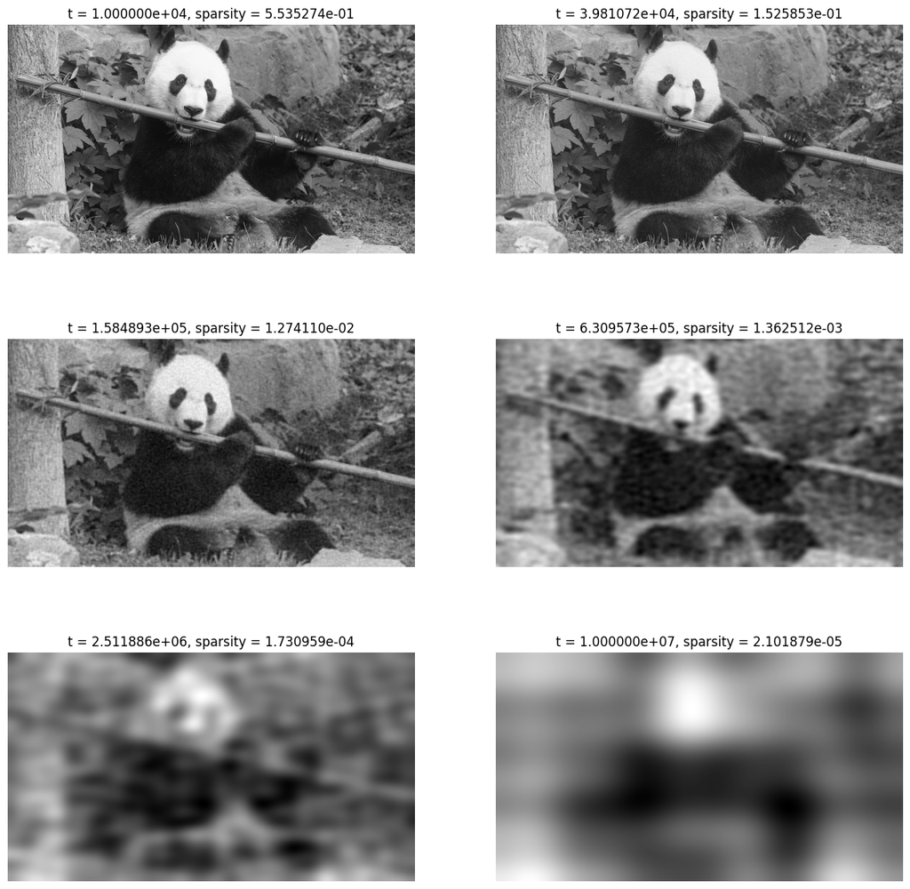

```python
import imageio.v2 as iio
import matplotlib.pyplot as plt
import numpy as np
import scipy.fftpack as transform

img = iio.imread("panda.png")
# generating grayscale image:
bw_img=np.sum(img,2)/3

# 2D DCT transform
coeffs= transform.dct(transform.dct(bw_img, axis=0),axis=1)
# Set a threshold t and threshold the coefficients in coeffs which will generate
num_of_t_dev_2 = 3
t = np.logspace(np.log10(1e4), np.log10(1e7), num=num_of_t_dev_2*2)

fig, axs = plt.subplots(num_of_t_dev_2, 2, figsize=(15, 5*num_of_t_dev_2))
for i in range(num_of_t_dev_2):
    for j in range(2):
        # Apply threshold
        approx_coeffs=coeffs*(abs(coeffs)>t[i*2+j])

        # Calculate sparsity
        sparsity = np.count_nonzero(approx_coeffs) / approx_coeffs.size


        # Apply 2d idct
        approx_img=transform.idct(transform.idct(approx_coeffs, axis=1),axis=0)
        #
        axs[i, j].imshow(approx_img, cmap='gray')
        axs[i, j].set_title(f"t = {t[i*2+j].__format__('e')}, sparsity = {sparsity.__format__('e')}")
        axs[i, j].axis('off')

plt.show()
```

a)

The proximal operator of the $\ell_1$ norm can be extended to vectors. Given a vector $\theta = [\theta_1, \theta_2, ..., \theta_n]^T$, the proximal operator of the $\ell_1$ norm is applied element-wise to $\theta$:

$$ prox_{\lambda||\cdot||_1}(\theta) = [S_\lambda(\theta_1), S_\lambda(\theta_2), ..., S_\lambda(\theta_n)]^T $$

where $S_\lambda(\cdot)$ is the shrinkage operator defined as:

$$ S_\lambda(x) = \begin{cases} x-\lambda & x \geq \lambda \\ x+\lambda & x \leq -\lambda \\ 0 & x \in(-\lambda, \lambda) \end{cases} $$

So, for each component $\theta_i$ of $\theta$, we apply the shrinkage operator $S_\lambda(\theta_i)$. This results in a vector where each component is shrunk towards zero by $\lambda$, which promotes sparsity in the solution.

b)

First we take the gradient of the objective function $LS(\theta)$ with respect to $\theta$ and we get

$$ \nabla LS(\theta) = -\frac{1}{n}X(y - X^T\theta) $$

Then we take a step with the gradient and update the parameter $\theta$ using:

$$ \theta^{(k+1)} = \theta^{(k)} - \mu \nabla LS(\theta^{(k)}) $$

Where $\mu$ is the learning rate.

Then we need to apply the Proximal Mapping operator of the $\ell_1$ norm to the updated parameter vector $\theta^{(k+1)}$:

$$ \theta^{(k+1)} = prox_{\lambda||\cdot||_1}(\theta^{(k+1)}) $$

where $prox_{\lambda||\cdot||_1}(\cdot)$ is the proximal operator of the $\ell_1$ norm, which is the shrinkage operator applied element-wise.

So, the update rule for a single iteration of the ISTA algorithm is:

$$ \theta^{(k+1)} = prox_{\lambda||\cdot||_1}(\theta^{(k)} - \mu \nabla LS(\theta^{(k)})) $$

#### c)

First we denote the residual as $e_k = y - \sum_{j \neq k} \xi_j \theta_j$.

and objective function then becomes:

$$ \min_{\theta_k} \frac{1}{2n} \left\| e_k - \xi_k \theta_k \right\|_2^2 + \lambda |\theta_k| $$

Taking the derivative of the above equation with respect to $\theta_k$ and setting it to zero, we get:

$$ \frac{1}{n} \xi_k^T (e_k - \xi_k \theta_k) = \lambda \cdot sign(\theta_k) $$

Solving for $\theta_k$, we get:

$$ \theta_k = \frac{ \xi_k^T e_k}{n \cdot ||\xi_k||^2_2} - \frac{\lambda}{||\xi_k||^2_2} \cdot sign(\theta_k) $$

This can be rewritten as:

$$ \theta_k = \frac{ S_{\lambda} \left( \frac{e^T_k\xi_k}{n} \right)}{\frac{||\xi_k||^2_k}{n}} $$

#### d)

The augmented Lagrangian for the LASSO problem with the constraint $\theta_1 = \theta_2$ is given by:

$$ L_\rho(\theta_1, \theta_2, \mu) = \frac{1}{2n}\left\|y - X^T \theta_1\right\|_2^2 + \lambda \|\theta_2\|_1 + \mu^T(\theta_1 - \theta_2) + \frac{\rho}{2}\left\|\theta_1 - \theta_2\right\|_2^2 $$

Where the parameter $\rho$ is the penalty parameter. The augmented Lagrangian is minimized with respect to $\theta_1$ and $\theta_2$ and maximized with respect to $\mu$. The update rules for the ADMM algorithm are given by:

$$ \theta_1^{(t+1)} = \arg\min_{\theta_1} L_\rho(\theta_1, \theta_2^{(t)}, \mu^{(t)}) $$

$$ \theta_2^{(t+1)} = \arg\min_{\theta_2} L_\rho(\theta_1^{(t+1)}, \theta_2, \mu^{(t)}) $$

$$ \mu^{(t+1)} = \mu^{(t)} + \rho(\theta_1^{(t+1)} - \theta_2^{(t+1)}) $$

Minimizing the augmented Lagrangian with respect to $\theta_1$. We denote the augmented Lagrangian as $L(\theta_1)$:

$$ L(\theta_1) = \frac{1}{2n}\left\|y - X^T \theta_1\right\|_2^2 + \lambda \|\theta_2\|_1 + \mu^T(\theta_1 - \theta_2) + \frac{\rho}{2}\left\|\theta_1 - \theta_2\right\|_2^2 $$

Take the derivative of $L(\theta_1)$ with respect to $\theta_1$ and set it equal to zero:

$$ \begin{align*} 0 &= \frac{\partial}{\partial \theta_1} L(\theta_1) \\ &= -\frac{1}{n}X(y - X^T \theta_1) + \mu + \rho(\theta_1 - \theta_2) \\ &= -\frac{1}{n}Xy + \frac{1}{n}X X^T \theta_1 + \mu + \rho \theta_1 - \rho \theta_2 \\ &= \frac{1}{n}X X^T \theta_1 + \rho \theta_1 - \frac{1}{n}Xy + \mu - \rho \theta_2 \\ &= \left(\frac{1}{n}X X^T + \rho I\right) \theta_1 + \mu - \rho \theta_2 - \frac{1}{n}Xy \end{align*} $$

Solving for $\theta_1$:

$$ \theta_1 = \left(\frac{1}{n}X X^T + \rho I\right)^{-1} \left(\rho \theta_2 - \mu + \frac{1}{n}Xy\right) $$

Minimize the augmented Lagrangian with respect to $\theta_2$. We denote the augmented Lagrangian as $L(\theta_2)$:

$$ L(\theta_2) = \frac{1}{2n}\left\|y - X^T \theta_1\right\|_2^2 + \lambda \|\theta_2\|_1 + \mu^T(\theta_1 - \theta_2) + \frac{\rho}{2}\left\|\theta_1 - \theta_2\right\|_2^2 $$

Derivative of $L(\theta_2)$ with respect to $\theta_2$ and set it equal to zero:

$$ \begin{align*} 0 &= \frac{\partial}{\partial \theta_2} L(\theta_2) \\ &= \lambda \text{sign}(\theta_2) - \mu - \rho(\theta_1 - \theta_2) \\ \end{align*} $$

solving for $\theta_2$:

$$ \theta_2 = \frac{\mu + \rho \theta_1 - \lambda sign(\theta_2)}{\rho} $$

and this can be written as:

$$ \theta_2 = S_{\frac{\lambda}{\rho}} \left( \theta_1 + \frac{\mu}{\rho} \right) $$

And $\mu$ is given from the augmented Lagrangian as:

$$ \mu^{(t+1)} = \mu^{(t)} + \rho(\text{Updated Constraint}) $$

and from that we get:

$$ \mu^{(t+1)} = \mu^{(t)} + \rho(\theta_1^{(t+1)} - \theta_2^{(t+1)}) $$

```
Converged after 14159 iterations:
Converged after 19 iterations:
Converged after 17861 iterations:
```

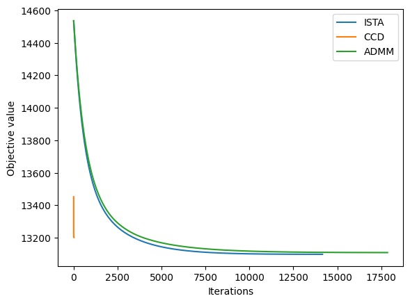

```python
import matplotlib.pyplot as plt
import numpy as np
from sklearn.datasets import load_diabetes
np.random.seed(0)

def soft_threshold(x, lambda_):
    if x >= lambda_:
        return x-lambda_
    elif x <= -lambda_:
        return x+lambda_
    else:
        return 0


def calculate_obj_ISTA(x, y, theta, lamb):
    return np.sum((y - np.dot(x, theta))**2)/(2*len(x)) + lamb*np.linalg.norm(theta)

def LASSO_ISTA(x, y, lam=0.1, max_iter=1000, tol=1e-4):
    theta = []
    obj_val = []
    theta.append(np.random.normal(size=(x.shape[1]))*0)
    for iter in range(max_iter):
        grad = np.dot(x.T, (y - np.dot(x, theta[-1])))/len(x)
        theta_hat = theta[-1] + lam*grad
        for t in theta_hat:
            t = soft_threshold(t, lam)

        theta.append(theta_hat)
        obj_val.append(calculate_obj_ISTA(x, y, theta[-1], lam))
        # Check for convergence
        if len(obj_val) > 1 and abs(obj_val[-1] - obj_val[-2]) < tol:
            print(f"Converged after {iter} iterations:")
            break
    return theta, obj_val

def objective_value_CCD(X, y, theta, lambd):
    n = len(y)
    residual = y - np.dot(X, theta)
    return  np.sum(residual**2) / (2*n) + lambd * np.sum(np.abs(theta))

def LASSO_CCD(X, y, lam, max_iters=1000, tol=1e-4):
    n, m = X.shape
    theta = np.zeros(m)
    obj_values = []

    for iter in range(max_iters):
        theta_old = np.copy(theta)

        for k in range(m):
            e_k = y - np.dot(X[:, np.arange(m) != k], theta[np.arange(m) != k])
            theta[k] = soft_threshold(np.dot(X[:, k].T, e_k) / n, lam) / (np.dot(X[:, k].T, X[:, k]) / n)

        # Calculate and store the objective value at each iteration
        obj_values.append(objective_value_CCD(X, y, theta, lam))

        # Check for convergence
        if max_iter>200:
            if len(obj_values) > 1 and abs(obj_values[-1] - obj_values[-2]) < tol:
                print(f"Converged after {iter} iterations:")
                break

    return theta, obj_values



def objective_value_ADMM(x, y, theta1, theta2, lambd):
    n = len(y)
    return  (np.sum((y - np.dot(x, theta1))**2) / (2*n)) + lambd * np.linalg.norm(theta2)

def LASSO_ADMM(x, y, lam=0.1, max_iter=1000, tol=1e-4, rho=1):
    obj_val = []
    theta1 = []
    theta2 = []
    n, p = x.shape
    XTX_inv = np.linalg.inv(np.dot(x.T, x)/n + rho*np.identity(p))
    XTy = np.dot(y, x)/n
    theta1.append(np.zeros(p))
    theta2.append(np.zeros(p))
    mu = np.zeros(p)

    for iter in range(max_iter):
        # Update theta1 using soft-thresholding
        theta1.append(np.dot(XTX_inv, rho*theta2[-1] - mu + XTy ))
        # Update theta2 using soft-thresholding
        theta_temp = theta1[-1] + (mu/rho)
        theta_temp2 = []
        for t in theta_temp:
            theta_temp2.append(soft_threshold(t, lam/rho))

        theta2.append(np.array(theta_temp2))

        mu = mu + rho*(theta1[-1] - theta2[-1])

        obj_val.append(objective_value_ADMM(x, y, theta1[-1], theta2[-1], lam))
        # Check for convergence
        if len(obj_val) > 1 and abs(obj_val[-1] - obj_val[-2]) < tol:
            print(f"Converged after {iter} iterations:")
            break

    return theta1, theta2, obj_val


step_size = 0.1
max_iter = 100000
tol = 1e-4
rho = 10

# Load the dataset
x = load_diabetes().data
y = load_diabetes().target
theta_ista, obj_val_ista = LASSO_ISTA(x, y, lam=step_size, max_iter=max_iter, tol=tol)
theta_ccd, obj_val_ccd = LASSO_CCD(x, y, lam=step_size, max_iters=max_iter, tol=tol)
theta1, theta2, objective_val = LASSO_ADMM(x, y, lam=step_size, max_iter=max_iter, tol=tol, rho=rho)
plt.plot(obj_val_ista, label="ISTA")
plt.plot(obj_val_ccd, label="CCD")
plt.plot(objective_val, label="ADMM")
plt.xlabel("Iterations")
plt.ylabel("Objective value")
plt.legend()
plt.show()
```

```
Converged after 14159 iterations:
Converged after 7 iterations:
Converged after 17861 iterations:
Converged after 21938 iterations:
Converged after 21498 iterations:
Converged after 20584 iterations:
Converged after 19503 iterations:
Converged after 18387 iterations:
Converged after 17294 iterations:
Converged after 16785 iterations:
Converged after 15613 iterations:
Converged after 14511 iterations:
Converged after 15678 iterations:
Converged after 14478 iterations:
Converged after 13427 iterations:
Converged after 12488 iterations:
Converged after 11633 iterations:
Converged after 10843 iterations:
Converged after 10100 iterations:
Converged after 10154 iterations:
Converged after 9771 iterations:
Converged after 9395 iterations:
Converged after 9057 iterations:
Converged after 8749 iterations:
Converged after 8469 iterations:
Converged after 8212 iterations:
Converged after 7975 iterations:
Converged after 7756 iterations:
Converged after 7553 iterations:
Converged after 7363 iterations:
Converged after 7184 iterations:
Converged after 7017 iterations:
Converged after 6858 iterations:
Converged after 6708 iterations:
Converged after 6565 iterations:
Converged after 6428 iterations:
Converged after 6297 iterations:
Converged after 6170 iterations:
Converged after 6049 iterations:
Converged after 5931 iterations:
```

[output cut: 48 more lines]

```
Converged after 14111 iterations:
Converged after 13772 iterations:
Converged after 13410 iterations:
Converged after 13022 iterations:
Converged after 12606 iterations:
Converged after 12160 iterations:
Converged after 11680 iterations:
Converged after 11162 iterations:
Converged after 10603 iterations:
Converged after 9996 iterations:
Converged after 9335 iterations:
Converged after 8611 iterations:
Converged after 7812 iterations:
Converged after 6923 iterations:
Converged after 5919 iterations:
```

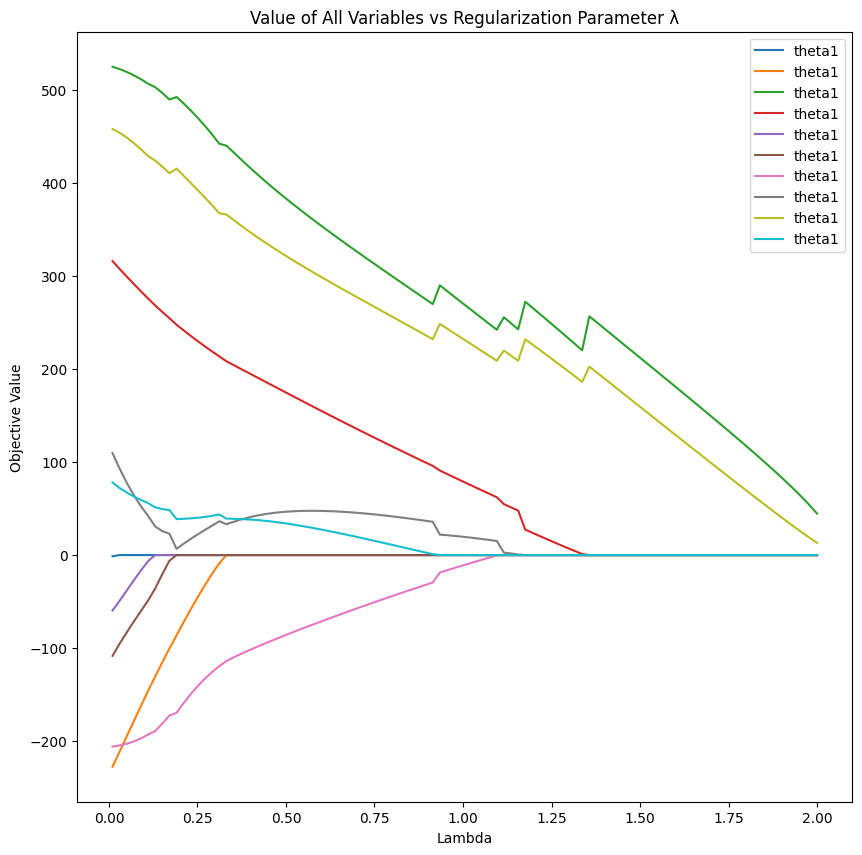

```python
import numpy as np
from sklearn.datasets import load_diabetes
import matplotlib.pyplot as plt
n = 100
d = 10
x = np.random.normal(size=(n, d), loc=0, scale=1)
y = np.random.normal(size=(n), loc=0, scale=1 )

lam = 0.1
max_iter = 100000
tol = 1e-4
rho = 10


# Load the dataset
x = load_diabetes().data
y = load_diabetes().target

# Set the parameters
max_iter = 100000
tol = 1e-4
rho = 10

# Apply ISTA
ista_theta, ista_obj_val = LASSO_ISTA(x, y, lam=lam, max_iter=max_iter, tol=tol)

# Apply CCD
ccd_theta, ccd_obj_val = LASSO_CCD(x, y, lam=0.5, max_iters=max_iter, tol=tol)

# Apply ADMM
admm_obj_val = LASSO_ADMM(x, y, lam=lam, max_iter=max_iter, tol=tol, rho=rho)

# Plot the value of all variables vs the regularization parameter λ
lambdas = np.linspace(0.01, 2, 100)
opt_obj_val = 0
theta1_lam = []
theta2_lam = []
lam_val = 0
obj_val_arr = []
for i, lam in enumerate(lambdas):
    theta1, theta2, obj_val = LASSO_ADMM(x, y, lam=lam, max_iter=max_iter, tol=tol, rho=rho)
    theta1_lam.append(theta1[-1])
    theta2_lam.append(theta2[-1])
    obj_val_arr.append(obj_val[-1])
    if round(lam, 2) == 0.5:
        opt_obj_val = obj_val[-1]
        lam_val = lam
        print(opt_obj_val)

plt.figure(figsize=(10, 10))
plt.plot(lambdas, theta1_lam, label=f"theta1")
plt.xlabel("Lambda")
plt.ylabel("Objective Value")
plt.title("Value of All Variables vs Regularization Parameter λ")
plt.legend()
plt.show()
```

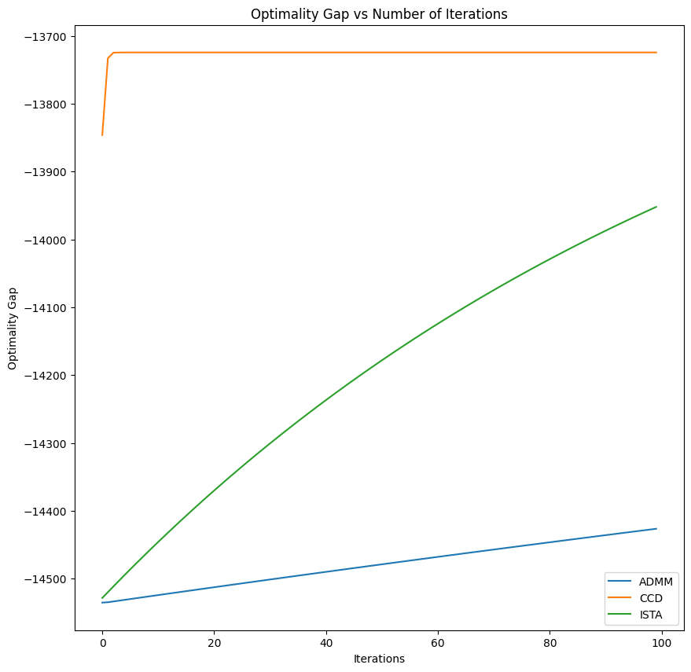

```python
plt.figure(figsize=(10, 10))
max_iter = 100
la = 0.5
tol = 1e-32
int_val_arr = np.linspace(0.01, 0.9, 10)


theta_ista, obj_val_ista = LASSO_ISTA(x, y, lam=la, max_iter=max_iter, tol=tol)
theta_ccd, obj_val_ccd = LASSO_CCD(x, y, lam=la, max_iters=max_iter, tol=tol)
theta1_admm, theta2_admm, obj_val_admm = LASSO_ADMM(x, y, lam=la, max_iter=max_iter, tol=tol, rho=rho)


optimality_gap_admm = [opt_obj_val - obj_val for obj_val in obj_val_admm]
optimality_gap_ccd= [opt_obj_val - obj_val for obj_val in obj_val_ccd]
optimality_gap_ista = [opt_obj_val - obj_val for obj_val in obj_val_ista]


plt.plot(optimality_gap_admm, label=f"ADMM")
plt.plot(optimality_gap_ccd, label=f"CCD")
plt.plot(optimality_gap_ista, label=f"ISTA")
plt.legend()
plt.xlabel("Iterations")
plt.ylabel("Optimality Gap")
plt.title("Optimality Gap vs Number of Iterations")
plt.show()
```